# datadr: housing example

jharner

February 24, 2015

We will use as an example a data set consisting of the median list and sold price of homes in the United States, aggregated by county and month from 2008 to early 2014.

#### Package installation

```
# install package with housing data
devtools::install_github("hafen/housingData")
```

#### Environment setup

Load the packages and look at the housing data

```r
library(housingData)
class(housing)
```

```
## [1] "data.frame"
```

```r
library(datadr);
library(trelliscope)
# look at housing data
head(housing)
```

```
##    fips         county state       time nSold medListPriceSqft
## 1 06001 Alameda County    CA 2008-10-01    NA         307.9787
## 2 06001 Alameda County    CA 2008-11-01    NA         299.1667
## 3 06001 Alameda County    CA 2008-11-01    NA               NA
## 4 06001 Alameda County    CA 2008-12-01    NA         289.8815
## 5 06001 Alameda County    CA 2009-01-01    NA         288.5000
## 6 06001 Alameda County    CA 2009-02-01    NA         287.0370
##   medSoldPriceSqft
## 1         325.8118
## 2               NA
## 3         318.1150
## 4         305.7878
## 5         291.5977
## 6               NA
```

#### Division by county and state

Divide the data is by county name and state to be able to study how home prices have evolved over time within county. We can do this with a call to `divide()`:

```r
# divide by county and state
byCounty <- divide(housing, by = c("county", "state"), update = TRUE)
```

```
## * Running map/reduce to get missing attributes...
```

```r
class(byCounty)
```

```
## [1] "ddf"      "ddo"      "kvMemory"
```

Our `byCounty` object is now a distributed data frame (ddf). We can see some of its attributes by printing the object:

```r
byCounty
```

```
##
## Distributed data frame backed by 'kvMemory' connection
##
##  attribute      | value
## ----------------+-----------------------------------------------------------
##  names          | fips(cha), time(Dat), nSold(num), and 2 more
##  nrow           | 224369
##  size (stored)  | 16.45 MB
##  size (object)  | 16.45 MB
##  # subsets      | 2883
##
## * Other attributes: getKeys(), splitSizeDistn(), splitRowDistn(), summary()
## * Conditioning variables: county, state
```

There are 2883 counties, and we can access various attributes by calling methods such as `summary()`. The `update = TRUE` that we added to `divide()` provided some of these attributes.

```r
# look at summaries
summary(byCounty)
```

```
##         fips                 time                nSold
##  -------------------  ------------------  -------------------
##        levels : 2883  missing :        0   missing :   164370
##       missing : 0         min : 08-10-01       min :       11
##  > freqTable head <       max : 14-03-01       max :    35619
##  26077 : 140                                  mean : 274.6582
##  51069 : 140                               std dev : 732.2429
##  08019 : 139                              skewness :   10.338
##  13311 : 139                              kurtosis : 222.8995
##  -------------------  ------------------  -------------------
##    medListPriceSqft     medSoldPriceSqft
##  --------------------  -------------------
##   missing :     48399   missing :   162770
##       min : 0.5482456       min : 17.40891
##       max :  1544.944       max : 1249.494
##      mean :  96.72912      mean : 105.5659
##   std dev :  56.12035   std dev : 69.40658
##  skewness :  6.816523  skewness : 5.610013
##  kurtosis :  94.06555  kurtosis : 60.48337
##  --------------------  -------------------
```

Since datadr knows that byCounty is a ddf, and we set update = TRUE, after the division operation it computed global summary statistics for each of the variables.

# look at overall distribution of median list price

`datadr` can compute a more meaningful global summary in a division-independent way with `drQuantile()`. For example, let’s look at quantiles for the median list price:

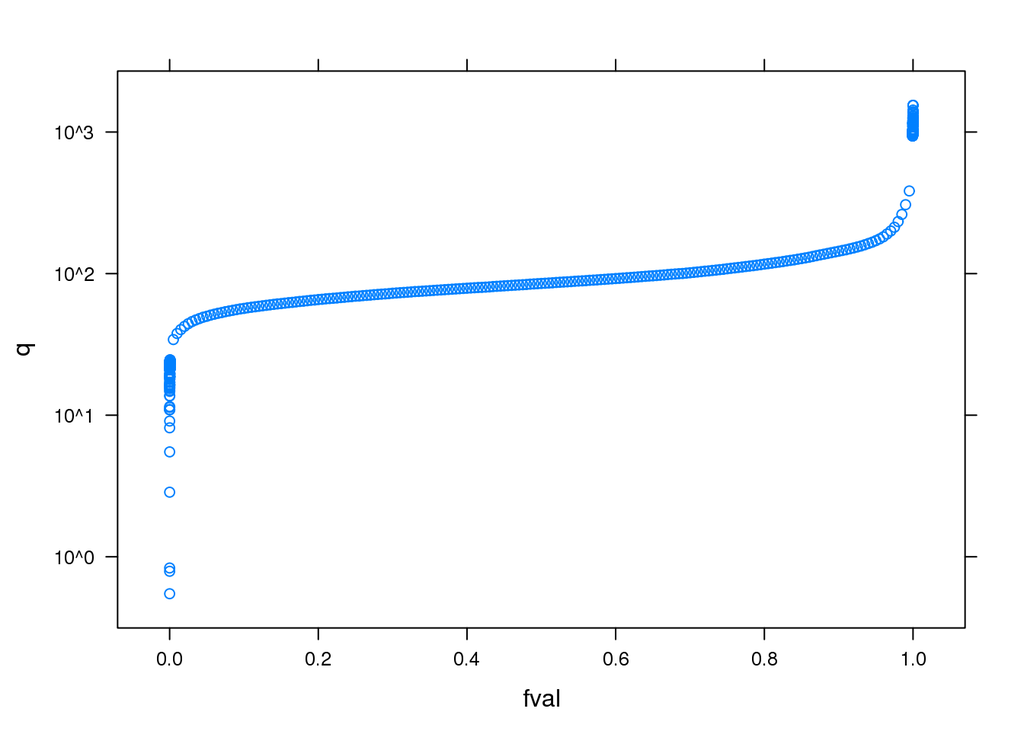

```r
priceQ <- drQuantile(byCounty, var = "medListPriceSqft")
xyplot(q ~ fval, data = priceQ, scales = list(y = list(log = 10)))
```

What does a subset of byCounty look like? `byCounty` is a list of key-value pairs. Essentially, the collection of subsets can be thought of as a large list, where each list element has a key and a value. To look at the first key-value pair:

```r
byCounty[[1]]
```

```
## $key
## [1] "county=Abbeville County|state=SC"
##
## $value
##    fips       time nSold medListPriceSqft medSoldPriceSqft
## 1 45001 2008-10-01    NA         73.06226               NA
## 2 45001 2008-11-01    NA         70.71429               NA
## 3 45001 2008-12-01    NA         70.71429               NA
## 4 45001 2009-01-01    NA         73.43750               NA
## 5 45001 2009-02-01    NA         78.69565               NA
## ...
```

#### Applying an analytic method and recombination

Apply an analytic method to each subset of our data and recombine the result. Let’s look at is the slope coefficient of a linear model applied to list prices vs. time for each county.

We can create a function that operates on an input data frame `x` that does this:

```r
# slope of fitted line of list price for each county
lmCoef <- function(x)
  coef(lm(medListPriceSqft ~ time, data = x))[2]
```

Apply this transformation to each subset in our data with `addTransform()`:

```r
# apply lmCoef to each subset
byCountySlope <- addTransform(byCounty, lmCoef)
```

```
## *** finding global variables used in 'fn'... [none]
##   package dependencies: stats
## *** testing 'fn' on a subset... ok
```

```r
class(byCountySlope)
```

```
## [1] "transformed" "ddo"         "kvMemory"
```

This applies `lmCoef()` to each subset in a deferred fashion, meaning that for all intents and purposes we can think of `byCountySlope` as a distributed data object that contains the result of `lmCoef()` being applied to each subset. But computation is deffered until another data operation is applied to `byCountySlope`, such as a recombination, which we will do next.

When we look at a subset of byCountySlope, we see what the result will look like:

```r
# look at a subset of transformed data
byCountySlope[[1]]
```

```
## $key
## [1] "county=Abbeville County|state=SC"
##
## $value
##          time
## -0.0002323686
```

recombine the slopes into a single data frame. This can be done with the `recombine()` function, using the `combRbind` combiner:

```r
# recombine all slopes into a single data frame
countySlopes <- recombine(byCountySlope, combRbind)
```

```
## * Verifying suitability of 'output' for specified 'combine'...
## * Applying recombination...
```

```r
head(countySlopes)
```

```
##                 county state           val
## time  Abbeville County    SC -0.0002323686
## time1    Acadia Parish    LA  0.0019518441
## time2  Accomack County    VA -0.0092717711
## time3       Ada County    ID -0.0030197554
## time4     Adair County    IA -0.0308381951
## time5     Adair County    KY  0.0034399585
```

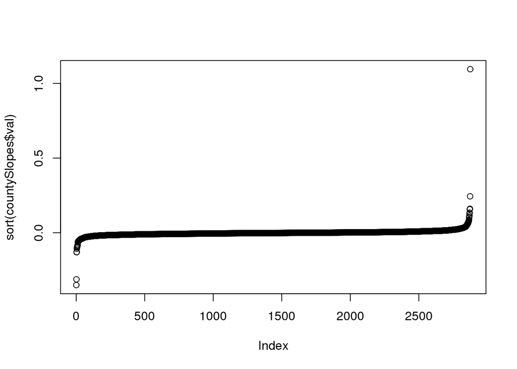

```r
plot(sort(countySlopes$val))
```

#### Joining other data sets

There are data operations beyond `divide()` and `recombine()`, e.g., `drJoin()`. Suppose we have multiple related data sources. For example, we have geolocation data for the county centroids. `drJoin()` will allow us to join multiple data sets by key.

We have a data set, `geoCounty`, part of the housingData package, that we want to divide in the same way as we divided the housing data:

```r
head(geoCounty)
```

```
##    fips         county state       lon      lat rMapState rMapCounty
## 1 01001 Autauga County    AL -86.64565 32.54009   alabama    autauga
## 2 01003 Baldwin County    AL -87.72627 30.73831   alabama    baldwin
## 3 01005 Barbour County    AL -85.39733 31.87403   alabama    barbour
## 4 01007    Bibb County    AL -87.12526 32.99902   alabama       bibb
## 5 01009  Blount County    AL -86.56271 33.99044   alabama     blount
## 6 01011 Bullock County    AL -85.71680 32.10634   alabama    bullock
```

```r
geo <- divide(geoCounty, by = c("county", "state"))
geo[[1]]
```

```
## $key
## [1] "county=Abbeville County|state=SC"
##
## $value
##    fips       lon      lat      rMapState rMapCounty
## 1 45001 -82.45851 34.23021 south carolina  abbeville
```

This division gives us a divided data set with the same keys as `byCounty`. So we can join this with byCounty:

```r
byCountyGeo <- drJoin(housing = byCounty, geo = geo)
class(byCountyGeo)
```

```
## [1] "ddo"      "kvMemory"
```

This providet us with a new ddo (not a data frame anymore) where for each key, the value is a list with a data frame housing holding the time series data and a data frame geo holding the geographic data. We can see the structure of this for a subset with:

```r
str(byCountyGeo[[1]])
```

```
## List of 2
##  $ key  : chr "county=Abbeville County|state=SC"
##  $ value:List of 2
##   ..$ housing:'data.frame':  66 obs. of  5 variables:
##   .. ..$ fips            : chr [1:66] "45001" "45001" "45001" "45001" ...
##   .. ..$ time            : Date[1:66], format: "2008-10-01" ...
##   .. ..$ nSold           : num [1:66] NA NA NA NA NA NA NA NA NA NA ...
##   .. ..$ medListPriceSqft: num [1:66] 73.1 70.7 70.7 73.4 78.7 ...
##   .. ..$ medSoldPriceSqft: num [1:66] NA NA NA NA NA NA NA NA NA NA ...
##   ..$ geo    :'data.frame':  1 obs. of  5 variables:
##   .. ..$ fips      : chr "45001"
##   .. ..$ lon       : num -82.5
##   .. ..$ lat       : num 34.2
##   .. ..$ rMapState : chr "south carolina"
##   .. ..$ rMapCounty: chr "abbeville"
##   ..- attr(*, "split")='data.frame': 1 obs. of  2 variables:
##   .. ..$ county: chr "Abbeville County"
##   .. ..$ state : chr "SC"
##  - attr(*, "class")= chr [1:2] "kvPair" "list"
```

### Trelliscope display

Trelliscope display is like a Trellis display, or ggplot with faceting, or small multiple plot, or whatever you are used to calling the action of breaking a set of data into pieces and applying a plot to each piece and then arranging those plots in a grid and looking at them. With Trelliscope, we are able to create such displays on data with a very large number of subsets and view them in an interactive and meaningful way.

#### Setting up a visualization database

For a Trelliscope display, connect to a “visualization database” (VDB), which is a directory on our computer where we are going to organize all of the information about our displays (we create many over the course of an analysis). Typically we will set up a single VDB for each project we are working on. We can do this with the `vdbConn()` function:

```r
# make a time series trelliscope display
vdbConn("housingjunk/vdb", autoYes = TRUE)
```

```
## vdb connection object: [name:none]; path=/Network/Servers/mozart.stat.wvu.edu/bayes/jharner/courses/stat624/datadr/housingEx/housingjunk/vdb
```

This connects to a directory called `vdb` relative to our current working directory. R holds this connection in its global options so that subsequent calls will know where to put things without explicitly specifying the connection each time.

#### Creating a panel function

To create a Trelliscope display, we need to first specify a panel function, which specifies what to plot for each subset. It takes as input either a key-value pair or just a value, depending on whether the function has two arguments or one.

Here is a panel function that takes a value and creates a lattice `xyplot` of list and sold price over time:

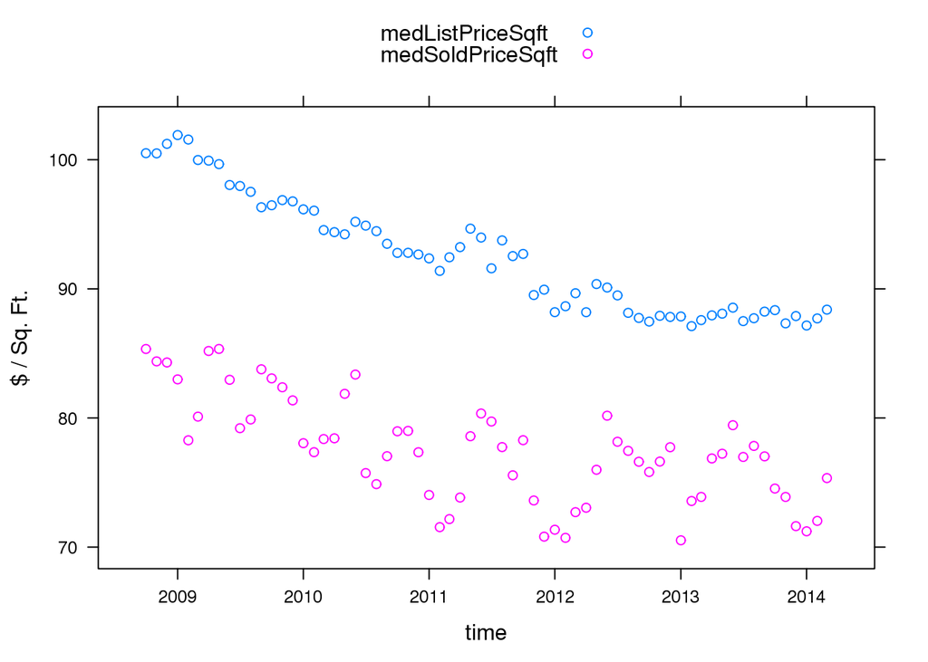

```r
# make and test panel function
timePanel <- function(x)
  xyplot(medListPriceSqft + medSoldPriceSqft ~ time,
    data = x, auto.key = TRUE, ylab = "$ / Sq. Ft.")
timePanel(byCounty[[20]]$value)
```

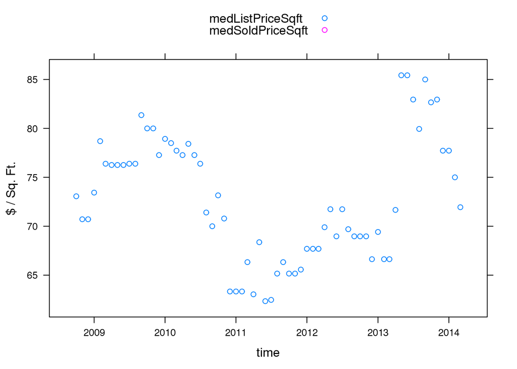

```r
timePanel(byCounty[[1]][[2]])
```

#### Creating a cognostics function

Specify a cognostics function for each subset. A cognostic is a metric that tells us an interesting attribute about a subset of data, and we can use cognostics to have more worthwhile interactions with all of the panels in the display. A cognostic function needs to return a list of metrics:

```r
# make and test cognostics function
priceCog <- function(x) { list(
  slope = cog(lmCoef(x), desc = "list price slope"),
  meanList = cogMean(x$medListPriceSqft),
  listRange = cogRange(x$medListPriceSqft),
  nObs = cog(sum(!is.na(x$medListPriceSqft)),
  desc = "number of non-NA list prices")
)}
```

We use the `cog()` function to wrap our metrics so that we can provide a description for the cognostic, and we also employ special cognostics functions `cogMean()` and `cogRange()` to compute mean and range with a default description.

We should test the cognostics function on a subset:

```r
priceCog(byCounty[[1]]$value)
```

```
## $slope
##          time
## -0.0002323686
##
## $meanList
## [1] 72.76927
##
## $listRange
## [1] 23.08482
##
## $nObs
## [1] 66
```

#### Making the display

Create a Trelliscope display by sending our data, our panel function, and our cognostics function to `makeDisplay()`:

```
# add display panel and cog function to vdb
makeDisplay(byCounty,
  name = "list_sold_vs_time",
  desc = "List and sold price over time",
  panelFn = timePanel, cogFn = priceCog,
  width = 400, height = 400,
  lims = list(x = "same"))
```

View the display with the following:

```
# view the display
view()
```